# Reproducible Research: Peer Assessment 1

MazinMelb

10 Jan 2016

## Overview

This report is considering the activity data recorded by a device collecting data at 5 minute intervals through out the day. The data consists of two months activity from an anonymous individual collected over two months, October and November, 2012 ,and includes the number of steps taken in 5 minute intervals each day.

## Loading and preprocessing the data

The data has been cleaned and transformed to facilitate visualisation and analysis. The time and date details have been converted into a ‘r’ date format (POSIXct) and there is a boolean field set to true for weekdays and false for weekends.

```r
setwd("~/Documents/RepData_PeerAssessment1")
fname <- "activity.csv"
activities <- read.csv(fname)

# add boolean for weekend / weekday
activities <- activities %>%
              mutate(weekday=
                  substr(weekdays(as.POSIXct(date)),1,1)!="S")

# add POXIXct class version of the interval
timechar <- str_pad(as.character(activities$interval),4,side="left",pad="0")
timeperiod <- sapply(timechar,function(x)
                    str_c(substr(x,1,2),":",substr(x,3,4)))

activities <- cbind(activities,timeperiod)
```

The data has been summarised by day, to show the total, mean and median number of steps by day.

```r
actsummary <- activities %>%
              group_by(date) %>%
              summarise(totsteps=sum(steps,na.rm=TRUE),
                        msteps = mean(steps,na.rm=TRUE),
                        medsteps = median(steps,na.rm=TRUE),
                        weekday=unique(weekday))
```

It has also been summarised by 5-minute interval to show the daily pattern of activity.

```r
daysummary <- activities %>%
      group_by(timeperiod) %>%
      summarise(totsteps = sum(steps,na.rm=TRUE),
            msteps = mean(steps,na.rm=TRUE),
            medsteps=median(steps,na.rm=TRUE),
            interval=unique(interval))

maxmsteps <- filter(daysummary,msteps==max(msteps))
nbtext <- paste("  NB: Maximum (average \n  in a 5 minute interval) \n  is",
                signif(maxmsteps$msteps,3),
                "steps at",maxmsteps$timeperiod)

# convert timeperiod into date/time format for graphing
maxmsteps$timeperiod=strptime(maxmsteps$timeperiod,format="%H:%M")
daysummary$timeperiod=strptime(daysummary$timeperiod,format="%H:%M")
```

# Summary of steps per day

## Total, the mean and the median steps per day (ignore NAs)

Visualising the number of steps each day highlights the missing values. As can be seen in the graph below, the median number of steps per day is significantly affected by the missing data. The total number of steps, and the mean and median number of steps taken per day is shown below:

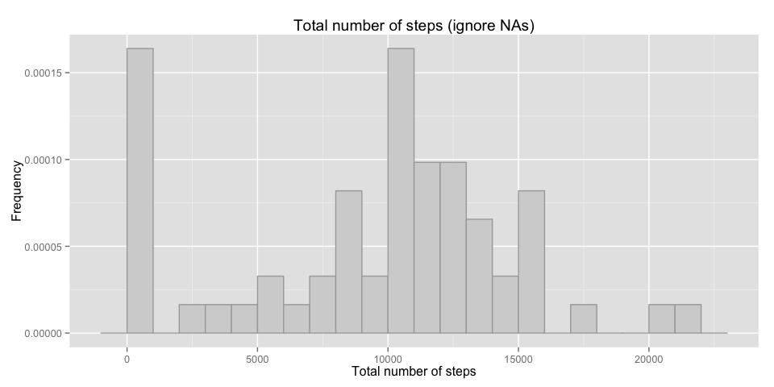

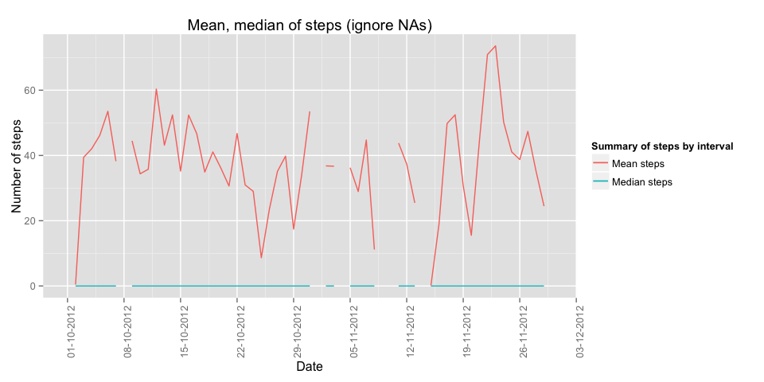

# Summary of daily activity pattern

## Daily pattern of activity (ignoring NAs)

The patern of daily activity, without imputing values for missing data, that is, any missing data has been ignormed, shows a difference in activity during the night hours (on the left and right of the graph), and the daytime hours (in the middle of the graph).

[figure not shown]

## Imputing missing values

```r
# replace na with mean for that interval using a split apply combine approach
activitiesValue <- filter(activities,!is.na(steps))
activitiesNA <- filter(activities,is.na(steps))

# replace na values with mean for that interval
meansteps <- merge(activitiesNA,daysummary,by="interval")
activitiesNA$steps <- meansteps$msteps

activities2 <- rbind(activitiesValue,activitiesNA)

# summarise steps per day with imputed values
actsummary2 <- activities2 %>%
               group_by(date) %>%
               summarise(totsteps=sum(steps,na.rm=TRUE),
                         msteps = mean(steps,na.rm=TRUE),
                         medsteps = median(steps,na.rm=TRUE),
                         weekday=unique(weekday))

# summarise steps per interval with imputed values
daysummary2 <- activities2 %>%
      group_by(timeperiod) %>%
      summarise(totsteps = sum(steps,na.rm=TRUE),
            msteps = mean(steps,na.rm=TRUE),
            medsteps=median(steps,na.rm=TRUE),
            interval=unique(interval))

daysummary2b <- activities2 %>%
                group_by(timeperiod, weekday) %>%
                summarise(totsteps = sum(steps,na.rm=TRUE),
                          interval=unique(interval))
daysummary2b$weekday <- sapply(daysummary2b$weekday, function(x)
                                ifelse(x,"Weekday","Weekend"))

maxmsteps <- filter(daysummary2,msteps==max(msteps))
nbtext <- paste("  NB: Maximum (average \n  in a 5 minute interval) \n  is",
                signif(maxmsteps$msteps,3),
                "steps at",maxmsteps$timeperiod)

# convert timeperiod into date/time format for graphing
maxmsteps$timeperiod=strptime(maxmsteps$timeperiod,format="%H:%M")
daysummary2$timeperiod=strptime(daysummary2$timeperiod,format="%H:%M")
```

## Daily pattern of activity (imputed values)

[figure not shown]

## Total number of steps taken per day (imputed values)

The pattern of median number of steps per interval still varies from the mean number of steps per interval because of the number of 0 values recorded for some intervals. Without a better understanding of the recording mechanism it is unclear whether it would be appropriate to replace ‘0’ values wiht the mean values.

The total number of steps, and the mean and median number of steps taken per day after replacing NAs with the mean values for that interval, are shown below:

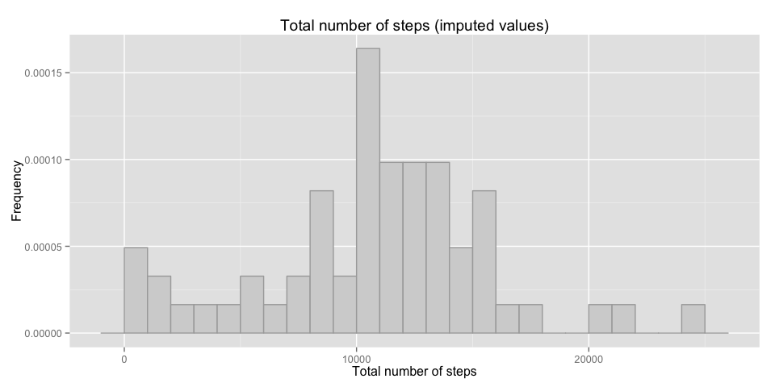

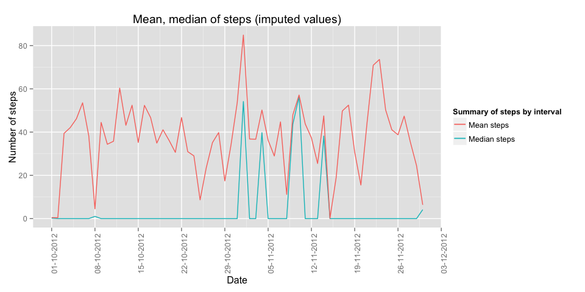

## Are there differences in activity patterns between weekdays and weekends?

The graph below visualises the different activities patterns between weekdays and weekends. As might be expected, there is less activty on the weekends and more activity (measured in total number of steps for each interval) on weekdays.

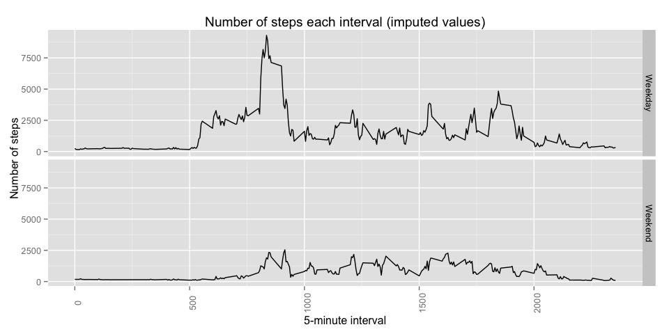